# Comparación de Modelos y Prueba de Hipótesis

En los apuntes anteriores hemos enfatizado el uso de técnicas y herramientas Bayesianas para resolver el problema de *inferencia paramétrica*: con base en cierto conjunto de observaciones $D$ y construyendo cierto modelo $M$ que tiene un conjunto de parámetros no observables $\theta$, hemos calculado las distribuciones posteriores $P(\theta|D)$ con `JAGS` (y Bayes, desde luego). En este sentido, en todos los ejemplos que hemos utilizado en el curso damos por sentado que el modelo $M$ es "verdadero", o "correcto", rara vez considerando otros modelos candidatos.

Sin embargo, en muchos escenarios aplicados y de investigación es deseable trabajar con más de un modelo o explicación posible sobre cierto fenómeno, con la idea de elegir la mejor explicación candidata a la luz de cierta evidencia $D$. Ver:

- Platt, J. (1964). Strong Inference. *Science, 146*, (3642), pp. 347-353.

Como se muestra en este apunte, también es posible utilizar técnicas Bayesianas para resolver este problema, conocido como el problema de *selección de modelos*, que puede frasearse como: *¿cuál modelo entre ciertos candidatos deberíamos conservar después de observar cierta evidencia $D$?*

Desde la perspectiva Bayesiana la respuesta a esta pregunta depende de dos factores: **1.** ¿qué tan probable es $D$ bajo cada modelo?, y **2.** ¿qué tan probable es cada modelo $M$ antes de observar $D$?

### Verosimilitud Marginal

Para ejemplificar consideren la relación entre el número de cigarros que cierta persona fuma al día, $k$, y la presencia o ausencia de cáncer pulmonar en su vida adulta, $z\in\{0,1\}$. Supondremos que $k$ es una variable no-observable, y que la única información observable es $D: z=1$. Es decir, que lo único que sabemos sobre cierta persona es que tiene cáncer pumonar, pero no sabemos nada sobre su hábito de fumar, o sobre la ausencia de éste.

Consideren además a tres equipos de investigación interesados en el tema, que visitan a la persona en el hospital y que tienen acceso a la información $D: z=1$. Si bien los tres equipos observan la misma pieza de evidencia, cada uno tiene creencias iniciales y funciones de verosimilitud diferentes.

El primer equipo, $M_1$, cree:

$$\begin{align} k &\in\{0,1,2,3\}\\ P(k) &= [0.2,0.3,0.4,0.1]\\ P(D|k) &= [0.1,0.2,0.2,0.1] \end{align}$$

Desde luego, con esta información podríamos calcular la incertidumbre posterior sobre $k$ utilizando Bayes:

$$P(k|D)=\frac{P(D|k)P(k)}{P(D)}$$

En donde el denominador $P(D)$ cuantifica la probabilidad de la evidencia $D$ **bajo este modelo**, en tanto que depende de la incertidumbre inicial $P(k)$ y de la función de verosimilitud $P(D|k)$, ambas **específicas de este equipo de investigación**:

$$P(D)=\sum_i P(D|k_i)P(k_i)$$

Sustituyendo:

$$\begin{align} P(D)&=\sum_i P(D|k_i)P(k_i)\\ &=P(D|k_1)P(k_1)+P(D|k_2)P(k_2)+P(D|k_3)P(k_3)+P(D|k_4)P(k_4)\\ &=(0.1)(0.2)+(0.2)(0.3)+(0.2)(0.4)+(0.1)(0.1)\\ &=0.02+0.06+0.08+0.01\\ &=0.17 \end{align}$$

El resultado $P(D)=0.17$ proporciona una idea de qué tan plausible es la observación $D:z=1$ desde la perspectiva del primer equipo, o bien de este modelo. Sin embargo es díficil interpretar su valor absoluto y tiene más sentido compararlo con los resultados del **segundo equipo**:

$$\begin{align} k &\in\{0,1 \mathrm{\ o\ más}\}\\ P(k) &= [0.2,0.8]\\ P(D|k) &= [0.2,0.3] \end{align}$$

En otras palabras, el segundo equipo considera escenarios más reducidos e hipótesis más concretas que el primero. Con la distribución a priori y la función de verosimilitud del segundo equipo obtenemos:

$$\begin{align} P(D)&=\sum_i P(D|k_i)P(k_i)\\ &=P(D|k_1)P(k_1)+P(D|k_2)P(k_2)\\ &=(0.2)(0.2)+(0.3)(0.8)\\ &=0.04+0.24\\ &=0.28 \end{align}$$

Finalmente, el **tercer equipo** es menos específico que los dos anteriores, en el sentido de que considera más escenarios posibles que pueden dar cuenta de la evidencia $D$, y además asigna el mismo peso a priori a cada uno de ellos:

$$\begin{align} k &\in\{0,1,2,3,4\}\\ P(k) &= [0.2,0.2,0.2,0.2,0.2]\\ P(D|k) &= [0.1,0.1,0.1,0.1,0.6] \end{align}$$

Calculando la verosimilitud marginal correspondiente a este modelo:

$$\begin{align} P(D)&=\sum_i P(D|k_i)P(k_i)\\ &=P(D|k_1)P(k_1)+P(D|k_2)P(k_2)+P(D|k_3)P(k_3)+P(D|k_4)P(k_4)+P(D|k_5)P(k_5)\\ &=(0.1)(0.2)+(0.1)(0.2)+(0.1)(0.2)+(0.1)(0.2)+(0.6)(0.2)\\ &=0.02+0.02+0.02+0.02+0.12\\ &=0.20 \end{align}$$

En otras palabras, la evidencia $D$ es más plausible desde la propuesta del segundo equipo, seguido del tercero y cerrando con el primero. En general, la **verosimilitud marginal** depende de las creencias iniciales sobre los no-observables, y de la función de verosimilitud de cada modelo: dos modelos con la misma estructura pero con a prioris diferentes pueden ser diferencialmente exitosos al explicar cierta evidencia observable.

### "Cuota" Posterior (*Posterior Odds*)

Desde el punto de vista Bayesiano los modelos en sí mismos pueden interpretarse como variables aleatorias, en el sentido de que podemos asignar creencias iniciales a la plausibilidad relativa entre diferentes modelos candidatos. En el caso de los equipos de investigación, por ejemplo, podríamos construir una distribución inicial $P(M_j)$ que representa qué tanta confianza le tenemos a cada uno de los tres equipos antes de observar la evidencia $D$.

Además, el interpretar a los diferentes modelos candidatos como variables aleatorias permite escribir las **verosimilitudes marginales** correspondientes como la distribución condicional:

$$P(D|M_j)=\sum_i P(D|k_i,M_j)P(k_i|M_j),$$

en donde $P(k_i|M_j)$ es la distribución a priori sobre $k$ **específica** del modelo $M_j$. Reescribiendo las verosimilitudes marginales previamente calculadas bajo esta interpretación:

$$\begin{align} P(D|M_1)&=\sum_i P(D|k_i,M_1)P(k_i|M_1)\\ &=(0.1)(0.2)+(0.2)(0.3)+(0.2)(0.4)+(0.1)(0.1)\\ &=0.17\\\\ P(D|M_2)&=\sum_i P(D|k_i,M_2)P(k_i|M_2)\\ &=(0.2)(0.2)+(0.3)(0.8)\\ &=0.28\\\\ P(D|M_3)&=\sum_i P(D|k_i,M_3)P(k_i|M_3)\\ &=(0.1)(0.2)+\dots+(0.6)(0.2)\\ &=0.20 \end{align}$$

Es decir, en tanto que la verosimilitud marginal de la evidencia $D$ es función del modelo $M_j$, y en tanto que el modelo $M_j$ es una variable aleatoria con peso a priori, *podríamos* calcular la probabilidad posterior del modelo $M_j$ como:

$$P(M_j|D)=\frac{P(D|M_j)P(M_j)}{P(D_{\mathrm{total}})},$$

en donde $P(D_{\mathrm{total}})$ es la probabilidad marginal de la evidencia **a través de todos los modelos**, y *podría* calcularse como:

$$P(D_{\mathrm{total}})=\sum_j P(D|M_j)P(M_j)$$

Sin embargo, en la mayoría de escenarios aplicados no es necesario calcular la "meta" verosimilitud marginal $P(D_{\mathrm{total}})$, porque tampoco es necesario calcular el peso posterior específico de cada modelo $P(M_j|D)$. La razón por la que no es necesario es porque rara vez nos interesa hablar sobre cada modelo en absoluto: la mayoría de las veces nos interesa comparar la plausibilidad relativa (posterior) entre modelos y para ello es posible tomar ciertos atajos.

Por ejemplo, después de observar la evidencia $D$ en el escenario de los equipos de investigación sobre cáncer pumonar, podría interesarnos comparar la plausibilidad relativa posterior (o *posterior odds*) entre $M_1$ y $M_2$:

$$\begin{align} posterior\ odds&=\frac{P(M_1|D)}{P(M_2|D)}\\\\ \frac{P(M_1|D)}{P(M_2|D)}&=\frac{\frac{P(D|M_1)P(M_1)}{P(D_{\mathrm{total}})}}{\frac{P(D|M_2)P(M_2)}{P(D_{\mathrm{total}})}}\\\\ \underbrace{\frac{P(M_1|D)}{P(M_2|D)}}_\text{Posterior Odds}&=\underbrace{\left(\frac{P(D|M_1)}{P(D|M_2)}\right)}_\text{Factor de Bayes}\ \ \underbrace{\left(\frac{P(M_1)}{P(M_2)}\right)}_\text{Prior Odds} \end{align}$$

En palabras, la plausibilidad relativa posterior entre dos modelos depende de 1. su plausibilidad relativa inicial (*prior odds*), y 2. la plausibilidad relativa de la evidencia entre ambos modelos (*Factor de Bayes*).

### Factor de Bayes

Si bien el resultado Bayesiano "completo" al comparar dos modelos consiste en las "cuotas" posteriores (posterior odds), esta cantidad rara vez se reporta porque depende de la plausibilidad relativa inicial de los modelos en consideración y, por lo tanto, dos investigadoras con creencias iniciales diferentes pueden alcanzar conclusiones posteriores diferentes sobre la plausibilidad de los modelos incluso bajo la misma evidencia $D$. En cambio, lo que suele reportarse y medirse con frecuencia es el *Factor de Bayes*, que cuantifica el apoyo relativo de cierta evidencia hacia cada uno de los modelos en consideración. La idea es que al reportar el Factor de Bayes estamos reportando **la consecuencia de nuestra evidencia** respecto de los modelos en estudio y, por lo tanto, diferentes investigadoras pueden utilizarla para actualizar sus creencias iniciales particulares.

Computacionalmente, el Factor de Bayes es la razón entre las verosimilitudes marginales de cierta evidencia $D$ entre dos modelos $M_1$ y $M_2$, y suele escribirse como:

$$\mathrm{BF_{12}}=\frac{P(D|M_1)}{P(D|M_2)}$$

,

que se lee "factor de Bayes de $M_1$ respecto de $M_2$". Esta razón cuantifica la *dirección* entre modelos favorecida por la evidencia $D$, que a grandes rasgos se interpreta:

$$\begin{align} \mathrm{BF_{12}}>1:&\ \mathrm{evidencia\ en\ favor\ de\ }M_1\\ \mathrm{BF_{12}}=1:&\ \mathrm{evidencia\ nula\ o\ ambigua}\\ \mathrm{BF_{12}}<1:&\ \mathrm{evidencia\ en\ favor\ de\ }M_2 \end{align}$$

Por ejemplo, calculando los factores de Bayes en el ejemplo de los tres equipos de investigación:

$$\begin{align} \mathrm{BF_{12}}=\frac{P(D|M_1)}{P(D|M_2)}=\frac{0.17}{0.28}\approx 0.60&:\ \mathrm{evidencia\ en\ favor\ de\ }M_2 {\mathrm{\ sobre\ }M_1}\\\\ \mathrm{BF_{31}}=\frac{P(D|M_3)}{P(D|M_1)}=\frac{0.20}{0.17}\approx 1.17&:\ \mathrm{evidencia\ en\ favor\ de\ }M_3 {\mathrm{\ sobre\ }M_1}\\\\ \mathrm{BF_{23}}=\frac{P(D|M_2)}{P(D|M_3)}=\frac{0.28}{0.20}= 1.4&:\ \mathrm{evidencia\ en\ favor\ de\ }M_2 {\mathrm{\ sobre\ }M_3}\\\\ \end{align}$$

Es decir, los factores de Bayes favorecen a $M_3$ sobre $M_1$, y a $M_2$ sobre $M_3$, lo cual permite afirmar que la evidencia favorece a $M_2$ sobre el resto de modelos. (Noten que el FB es transitivo: también favorece explícitamente a $M_2$ sobre $M_1$.)

Si reportamos estos factores, una lectora con la siguiente distribución a priori **sobre los equipos**:

$$P(M_j)=\begin{cases} P(M_1)=0.5\\ P(M_2)=0.3\\ P(M_3)=0.2, \end{cases}$$

que nuevamente muestran relaciones transitivas.

### Ejercicio

Considera los siguientes modelos y cierto conjunto de evidencia $D$, tal que:

$$\begin{align} M_1:&\\ P(\gamma|M_1)&=[0.25,0.25,0.25,0.25]\\ P(D|\gamma,M_1)&=[0.7,0.2,0.2,0.2]\\\\ M_2:&\\ P(\gamma|M_2)&=[0.25,0.25,0.25,0.25]\\ P(D|\gamma,M_2)&=[0.2,0.2,0.2,0.2]\\\\ M_3:&\\ P(\gamma|M_3)&=[0.1,0.1,0.7,0.1]\\ P(D|\gamma,M_3)&=[0.7,0.2,0.2,0.2],\\\\ \end{align}$$

y calcula los **factores de Bayes** entre ellos: ¿qué modelo es favorecido por la evidencia $D$?

### Solución

Calculando las **verosimilitudes marginales** de cada modelo:

$$\begin{align} P(D|M_1)&=\sum_i P(D|\gamma_i,M_1)P(\gamma_i|M_1)\\ &=(0.7)(0.25)+(0.2)(0.25)+(0.2)(0.25)+(0.2)(0.25\\ &=0.325\\\\ P(D|M_2)&=\sum_i P(D|\gamma_i,M_2)P(\gamma_i|M_2)\\ &=(0.2)(0.25)+(0.2)(0.25)+(0.2)(0.25)+(0.2)(0.25\\ &=0.2\\\\ P(D|M_3)&=\sum_i P(D|\gamma_i,M_3)P(\gamma_i|M_3)\\ &=(0.7)(0.1)+(0.2)(0.1)+(0.2)(0.7)+(0.2)(0.1)\\ &=0.25\\\\ \end{align}$$

Calculando los **Factores de Bayes**:

$$\begin{align} \mathrm{BF_{12}}=\frac{P(D|M_1)}{P(D|M_2)}=\frac{0.325}{0.2}= 1.625&:\ \mathrm{evidencia\ en\ favor\ de\ }M_1 {\mathrm{\ sobre\ }M_2}\\\\ \mathrm{BF_{31}}=\frac{P(D|M_3)}{P(D|M_1)}=\frac{0.25}{0.325}\approx 0.769&:\ \mathrm{evidencia\ en\ favor\ de\ }M_1 {\mathrm{\ sobre\ }M_3}\\\\ \mathrm{BF_{23}}=\frac{P(D|M_2)}{P(D|M_3)}=\frac{0.2}{0.25}= 0.8&:\ \mathrm{evidencia\ en\ favor\ de\ }M_3 {\mathrm{\ sobre\ }M_2}\\\\ \end{align}$$

Es decir, la evidencia favorece a los modelos en el orden $M_1>M_3>M_2.$

### Parámetros Continuos

Las herramientas anteriores, y el factor de Bayes en particular, pueden emplearse para seleccionar modelos que tienen no-observables continuos.

Para ejemplificar supongan que tenemos un examen de 10 preguntas, cada una con dos opciones de respuesta: una correcta y una incorrecta, y lo aplicamos a cierta persona. Antes de observar el resultado podemos considerar los siguientes dos modelos para predecir el número total de respuestas correctas $x$:

$$\begin{align} M_0:&\\ \theta&=0.5\\ x&\sim Binomial(\theta,10)\\\\ M_1:&\\ \theta&\sim Uniforme(0,1)\\ x&\sim Binomial(\theta,10) \end{align}$$

En palabras, el modelo $M_0$ corresponde con la hipótesis *"la persona responderá al azar"*, mientras que $M_1$ puede frasearse como *"la probabilidad de correcta por reactivo puede ser diferente de 0.5"*.

Con esta información podríamos calcular toda la distribución predictiva a priori sobre $x$ de cada modelo, o bien concentrarnos en el resultado **observado** $D: x=8$ y decidir a qué modelo favorece esta pieza de evidencia.

Calculando las **verosimilitudes marginales**:

$$\begin{align} P(D|M_0)&={10\choose 8}\theta^8(1-\theta)^{10-8}\\\\ &=45(0.5)^8(0.5)^2\\\\ &\approx0.0439\\\\ P(D|M_1)&=\int_\Theta P(D|\theta,M_1)P(\theta|M_1)d\theta\\\\ &=\int_0^1 {10 \choose 8}\theta^8(1-\theta)^{10-8}\frac{1}{1-0}d\theta\\\\ &=\int_0^1 45 \theta^8(1-\theta)^2 d\theta\\\\ &=45\int_0^1 \theta^8-2\theta^9+\theta^{10} d\theta\\\\ &=45\left.\left(\frac{\theta^9}{9}-2\frac{\theta^{10}}{10}+\frac{\theta^{11}}{11}\right)\right|_1-45\left.\left(\frac{\theta^9}{9}-2\frac{\theta^{10}}{10}+\frac{\theta^{11}}{11}\right)\right|_0\\\\ &=45\left(\frac{1}{9}-\frac{1}{5}+\frac{1}{11}\right)\\\\ &=45\left(\frac{55-99+45}{495}\right)\\\\ &=45\left(\frac{1}{495}\right)\\\\ &\approx 0.0909 \end{align}$$

Resumiendo con el factor de Bayes:

$$\begin{align} \mathrm{BF_{01}}&=\frac{P(D|M_0)}{P(D|M_1)}\\\\ &\approx\frac{0.0439}{0.0909}\\\\ &\approx0.482 \end{align}$$

,

es decir, la evidencia $D$ favorece a $M_1$: observar $x=8$ es más plausible si la persona no está respondiendo al azar, respecto de si lo está.

### El Método Savage-Dickey

El ejemplo anterior presenta la comparación entre "dos" modelos anidados: el modelo $\theta=0.5$ es un caso especial del modelo $\theta\in(0,1)$. Este tipo de comparaciones son utilizadas con frecuencia porque permiten responder preguntas sobre "efectos nulos", fraseadas como *¿el parámetro de interés es igual o diferente de cierto valor?* Para responder este tipo de preguntas **en modelos anidados** destaca el **método de Savage-Dickey**.

En concreto, el resultado indica que para calcular el Factor de Bayes del caso **anidado** respecto del modelo **general**, únicamente necesitamos el modelo **general**. En particular, el Factor de Bayes deseado puede calcularse diviendo la distribución posterior entre la distribución a priori del parámetro, evaluándolas en el valor criterio de interés. O, dicho de otra manera, el método Savage-Dickey permite calcular el Factor de Bayes **sin** calcular la verosimilitud marginal desde $M_0$, sino únicamente calculando la distribución posterior y a priori sobre $\theta$ de $M_1$, y evaluándolas en el valor de $\theta$ que corresponde al modelo anidado.

Por ejemplo, si nos interesa evaluar los modelos $M_0:\theta=0.5$ y $M_1:\theta\neq0.5$, Savage-Dickey permite calcular el Factor de Bayes como:

$$\mathrm{BF_{01}}=\frac{P(D|M_0)}{P(D|M_1)}=\frac{P(\theta=0.5|D,M_1)}{P(\theta=0.5|M_1)},$$

en donde el numerador es la distribución posterior sobre $\theta$ evaluada en $\theta=0.5$ y el denominador es la distribución a priori evaluada en el mismo valor, **ambas** desde $M_1$.

Resolviendo para los modelos anteriores:

$$\begin{align} \mathrm{prior\ sobre\ }\theta \mathrm{\ desde\ } M_1:&\\ P(\theta|M_1)&=\frac{1}{1-0}\\\\ &=1\\\\ \mathrm{posterior\ sobre\ }\theta \mathrm{\ desde\ } M_1:&\\ P(\theta|D,M_1)&=\frac{P(D|\theta,M_1)P(\theta|M_1)}{\int_\Theta P(D|\theta,M_1)P(\theta|M_1)d\theta}\\\\ &=\frac{45 \theta^8(1-\theta)^2}{\frac{45}{495}}\\\\ &=495\theta^8(1-\theta)^2\\\\ \end{align}$$$$\begin{align} \mathrm{Factor\ de \ Bayes\ (Savage-Dickey)}:&\\\\ \mathrm{BF_{01}}=\frac{P(D|M_0)}{P(D|M_1)}&=\frac{P(\theta=0.5|D,M_1)}{P(\theta=0.5|M_1)}\\\\ &=\frac{495(0.5)^8(1-0.5)^2}{1}\\\\ &\approx0.482, \end{align}$$

que reproduce el resultado obtenido al calcular las verosimilitudes marginales desde cada modelo.

Gráficamente, el método consiste en evaluar las alturas de la posterior respecto de la a priori en el valor crítico:

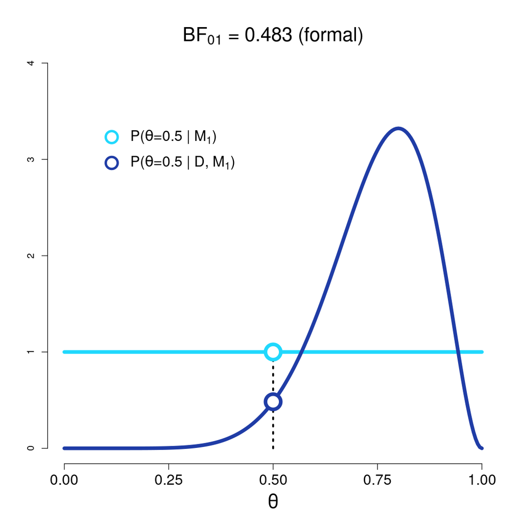

```r
rm(list=ls())
th <- seq(0,1,0.005)
prior <- function(th){
    return(rep(1,length(th)))
}
post <- function(th){
    return(495*th^8*(1-th)^2)
}

BF_01 <- post(0.5)/prior(0.5)

col_prior <- '#20d8fd'
col_post <- '#1f3ca6'

options(repr.plot.width = 9, repr.plot.height = 9)
plot(NULL,xlim=c(0,1),ylim=c(0,4),axes=F,ann=F)
axis(1,at=seq(0,1,0.25),cex.axis=1.5)
axis(2)
mtext('\u03b8',1,cex=2,line=3)
mtext(bquote(paste('BF'['01'],' = ',.(round(BF_01,3)),' (formal)')),3,cex=2)
# Solución analítica
lines(th,prior(th),lwd=6,col=col_prior)
lines(th,post(th),lwd=6,col=col_post)
lines(x=rep(0.5,2),y=c(0,prior(0.5)),lty='dotted',lwd=3)
points(x=rep(0.5,2),y=c(prior(0.5),post(0.5)),pch=21,cex=3.5,bg='#ffffff',lwd=6,
      col=c(col_prior,col_post))
# Anotaciones
legend(0.1,3.5,seg.len=0,col=c(col_prior,col_post),
      legend=c(expression(paste('P(',theta,'=0.5 | ',M[1],')')),
              expression(paste('P(',theta,'=0.5 | D, ',M[1],')'))),
      lwd=4,pch=21,pt.cex=2.75,pt.bg='#ffffff',cex=1.5,box.lty='blank')
```

### Savage-Dickey en JAGS

En el ejemplo anterior es posible calcular el Factor de Bayes de manera analítica, tanto por el camino de las verosimilitudes marginales, como utilizando el método Savage-Dickey. En aplicaciones prácticas, sin embargo, la solución analítica no siempre es accesible, pero afortunadamente podemos utilizar el resultado de `JAGS` para calcular el Factor de Bayes utilizando Savage-Dickey:

```r
x <- 8
n <- 10
obs <- list('x','n')
unobs <- c('theta_prior','theta_post')
write('
model{
    theta_prior~dunif(0,1)
    theta_post~dunif(0,1)
    x~dbinom(theta_post,n)
}
','binomial.bug')
library('R2jags')
set.seed(13)
bayes_binom <- jags(data = obs,
                  parameters.to.save = unobs,
                  model.file = 'binomial.bug',
                  n.chains = 3,
                  n.iter = 1000, # Probar n.iter=30000 para mejorar precisión del BF
                  n.burnin = 0,
                  n.thin=1)
nds_binom <- bayes_binom$BUGSoutput$sims.list
```

```r
summary(bayes_binom$BUGSoutput$summary[,'Rhat'])
summary(bayes_binom$BUGSoutput$summary[,'n.eff'])
```

```
   Min. 1st Qu.  Median    Mean 3rd Qu.    Max.
  1.002   1.004   1.005   1.004   1.006   1.006
```

```
   Min. 1st Qu.  Median    Mean 3rd Qu.    Max.
    470     500     530    1267    1665    2800
```

**La clave para calcular Savage-Dickey consiste en especificar los `breaks` del histograma de tal manera que el valor crítico sea un *punto medio* en las barras resultantes:**

```r
brks <- seq(0,1,length.out=20)
h_prior <- hist(nds_binom$theta_prior,breaks=brks,plot=F)
h_post <- hist(nds_binom$theta_post,breaks=brks,plot=F)
h_prior
```

```
$breaks
 [1] 0.00000000 0.05263158 0.10526316 0.15789474 0.21052632 0.26315789
 [7] 0.31578947 0.36842105 0.42105263 0.47368421 0.52631579 0.57894737
[13] 0.63157895 0.68421053 0.73684211 0.78947368 0.84210526 0.89473684
[19] 0.94736842 1.00000000

$counts
 [1] 159 152 152 172 161 162 159 130 190 138 157 152 164 166 146 163 158 137 182

$density
 [1] 1.0070000 0.9626667 0.9626667 1.0893333 1.0196667 1.0260000 1.0070000
 [8] 0.8233333 1.2033333 0.8740000 0.9943333 0.9626667 1.0386667 1.0513333
[15] 0.9246667 1.0323333 1.0006667 0.8676667 1.1526667

$mids
 [1] 0.02631579 0.07894737 0.13157895 0.18421053 0.23684211 0.28947368
 [7] 0.34210526 0.39473684 0.44736842 0.50000000 0.55263158 0.60526316
[13] 0.65789474 0.71052632 0.76315789 0.81578947 0.86842105 0.92105263
[19] 0.97368421

$xname
[1] "nds_binom$theta_prior"

$equidist
[1] TRUE

attr(,"class")
[1] "histogram"
```

```r
# ¿El valor 0.5 se encuentra en alguna posición de 'h_prior$mids'?
0.5%in%h_prior$mids
0.5%in%h_post$mids
```

TRUE

TRUE

```r
# ¿Cuál es el valor de densidad correspondiente a la barra con punto medio=0.5?
h_prior$density[h_prior$mids==0.5]
h_post$density[h_post$mids==0.5]
```

0.874

0.456

```r
# Calculando Savage-Dickey:
prior_dens <- h_prior$density[h_prior$mids==0.5]
post_dens <- h_post$density[h_post$mids==0.5]
BF_01 <- post_dens/prior_dens
BF_01
```

0.521739130434783

```r
# También podemos utilizar los conteos del histograma, en lugar de los valores de densidad:
prior_freq <- h_prior$counts[h_prior$mids==0.5]
post_freq <- h_post$counts[h_post$mids==0.5]
post_freq/prior_freq
```

0.521739130434783

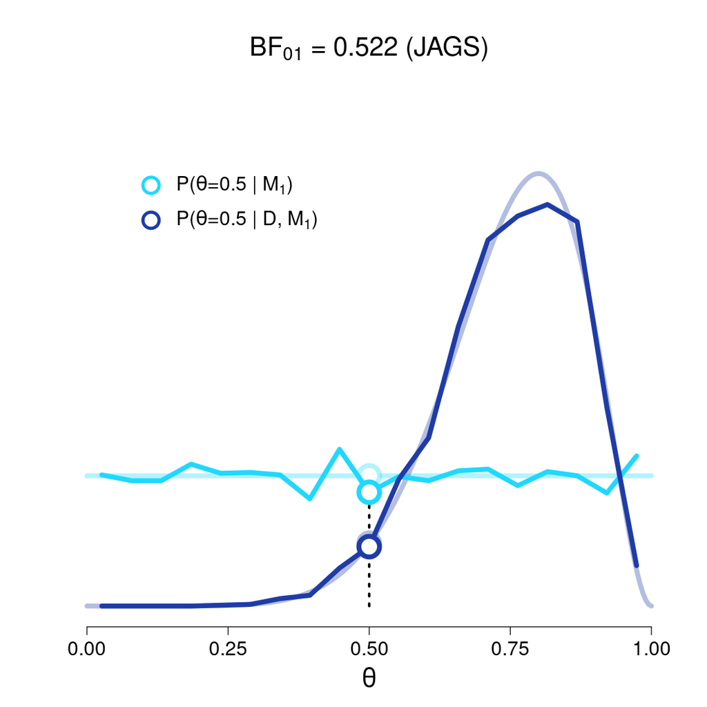

```r
th <- seq(0,1,0.005)
prior <- function(th){
    return(rep(1,length(th)))
}
post <- function(th){
    return(495*th^8*(1-th)^2)
}

col_prior <- '#20d8fd'
col_post <- '#1f3ca6'

options(repr.plot.width = 9, repr.plot.height = 9)
plot(NULL,xlim=c(0,1),ylim=c(0,4),axes=F,ann=F)
axis(1,at=seq(0,1,0.25),cex.axis=1.5)
mtext('\u03b8',1,cex=2,line=3)
mtext(bquote(paste('BF'['01'],' = ',.(round(BF_01,3)),' (JAGS)')),3,cex=2)
# Solución analítica
lines(th,prior(th),lwd=6,col=paste(col_prior,'55',sep=''))
lines(th,post(th),lwd=6,col=paste(col_post,'55',sep=''))
lines(x=rep(0.5,2),y=c(0,prior(0.5)),lty='dotted',lwd=3)
points(x=rep(0.5,2),y=c(prior(0.5),post(0.5)),pch=21,cex=3.5,bg='#ffffff',lwd=6,
      col=paste(c(col_prior,col_post),'55',sep=''))
# Solución numérica (JAGS)
lines(h_prior$mids,h_prior$density,lwd=6,col=col_prior)
lines(h_post$mids,h_post$density,lwd=6,col=col_post)
points(x=rep(0.5,2),y=c(h_prior$density[h_prior$mids==0.5],
                        h_post$density[h_post$mids==0.5]),
       pch=21,cex=3.5,bg='#ffffff',col=c(col_prior,col_post),lwd=6)
# Anotaciones
legend(0.1,3.5,seg.len=0,col=c(col_prior,col_post),
      legend=c(expression(paste('P(',theta,'=0.5 | ',M[1],')')),
              expression(paste('P(',theta,'=0.5 | D, ',M[1],')'))),
      lwd=4,pch=21,pt.cex=2.75,pt.bg='#ffffff',cex=1.5,box.lty='blank')
```

### Diferencia entre Tasas

Una de las aplicaciones más frecuentes y útiles del método S-D (y de la comparación de modelos en general), consiste en analizar las *diferencias* entre diferentes parámetros de un modelo.

Para ilustrar, supongan que estudiamos a dos "tiradores de dardos" y estamos interesados en decidir si alguno es mejor o si tienen habilidades similares. Para averiguarlo, los observamos ejecutar $n=20$ tiros, y registramos el número de "blancos": el primero obtiene $x_1=18$ éxitos, mientras que el segundo $x_2=12$.

Suponiendo independencia y distribución idéntica entre intentos, podemos utilizar el modelo siguiente para decidir si la **diferencia** entre las probabilidades de éxito de ambos tiradores, $\delta$, es igual o diferente de $0$:

$$\begin{align} \theta_1&\sim Uniform(0,1)\\ \theta_2&\sim Uniform(0,1)\\ \delta&\gets \theta_1-\theta_2\\ x_1&\sim Binomial(\theta_1,n)\\ x_2&\sim Binomial(\theta_2,n) \end{align}$$

[figure not shown]

```r
rm(list=ls())
# Problema original (en texto)
# Evidencia en CONTRA de M0 (BF_01<1)
x1 <- 18
x2 <- 12


# No dejen de probar los siguientes escenarios y evaluar los
# factores de Bayes en ellos:

# Evidencia en FAVOR de M0 (BF_01>1)
#x1 <- 15
#x2 <- 16

# Evidencia AMBIGUA (BF_01=1)
#x1 <- 15
#x2 <- 19

n <- 20
obs <- list('x1','x2','n')
unobs <- c('theta1_prior','theta1_post',
          'theta2_prior','theta2_post',
          'delta_prior','delta_post')
write('
model{
    # Unobservables
    theta1_prior~dunif(0,1)
    theta1_post~dunif(0,1)
    theta2_prior~dunif(0,1)
    theta2_post~dunif(0,1)
    delta_prior <- theta1_prior-theta2_prior
    delta_post <- theta1_post-theta2_post

    # Data
    x1~dbinom(theta1_post,n)
    x2~dbinom(theta2_post,n)
}
','delta.bug')
library('R2jags')
set.seed(13)
bayes_delta <- jags(data = obs,
                  parameters.to.save = unobs,
                  model.file = 'delta.bug',
                  n.chains = 3,
                  n.iter = 5000,
                  n.burnin = 0,
                  n.thin=1)
nds_delta <- bayes_delta$BUGSoutput$sims.list
```

```r
summary(bayes_delta$BUGSoutput$summary[,'Rhat'])
summary(bayes_delta$BUGSoutput$summary[,'n.eff'])
```

```
   Min. 1st Qu.  Median    Mean 3rd Qu.    Max.
  1.001   1.001   1.001   1.001   1.001   1.001
```

```
   Min. 1st Qu.  Median    Mean 3rd Qu.    Max.
   5000    8400   15000   11686   15000   15000
```

```r
brks <- seq(-1,1,length.out=50)
delta_prior <- hist(nds_delta$delta_prior,breaks=brks,plot=F)
delta_post <- hist(nds_delta$delta_post,breaks=brks,plot=F)
0%in%delta_prior$mids
0%in%delta_post$mids
prior_dens <- delta_prior$density[delta_prior$mids==0]
post_dens <- delta_post$density[delta_post$mids==0]
```

TRUE

TRUE

```r
# Bayes Factor
BF_01 <- post_dens/prior_dens
print(paste('Factor de Bayes para delta=0:',BF_01))
```

```
[1] "Factor de Bayes para delta=0: 0.296052631578947"
```

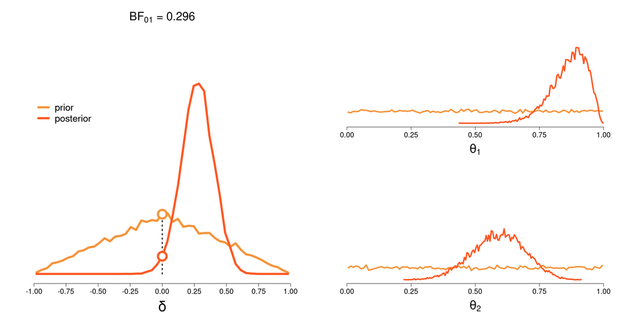

```r
col_prior <- '#f5943b'
col_post <- '#fd5925'

options(repr.plot.width = 18, repr.plot.height = 9)
layout(matrix(c(1,1,2,3),ncol=2,byrow=F))
# DELTA
plot(NULL,xlim=c(-1,1),ylim=c(0,4),axes=F,ann=F)
axis(1,at=seq(-1,1,0.25),cex.axis=1.5)
lines(delta_prior$mids,delta_prior$density,col=col_prior,lwd=6)
lines(delta_post$mids,delta_post$density,col=col_post,lwd=6)
lines(x=rep(0,2),y=c(0,max(prior_dens,post_dens)),lty='dotted',lwd=3)
points(x=rep(0,2),y=c(prior_dens,post_dens),pch=21,bg='#ffffff',cex=4,col=c(col_prior,col_post),lwd=6)
mtext('\u03b4',1,cex=2.5,line=4)
mtext(bquote(paste('BF'['01'],' = ',.(round(BF_01,3)))),3,cex=2)
legend(-1.2,3,legend=c('prior','posterior'),col=c(col_prior,col_post),
      lwd=6,seg.len=0.35,cex=2,x.intersp=0.2,y.intersp=0.65,
       bg='#ffffff00',text.width=.2,box.lty='blank')
# Theta
brks <- 100
theta1_prior <- hist(nds_delta$theta1_prior,breaks=brks,plot=F)
theta1_post <- hist(nds_delta$theta1_post,breaks=brks,plot=F)
theta2_prior <- hist(nds_delta$theta2_prior,breaks=brks,plot=F)
theta2_post <- hist(nds_delta$theta2_post,breaks=brks,plot=F)
# theta_1
plot(NULL,xlim=c(0,1),ylim=c(0,8),axes=F,ann=F)
axis(1,at=seq(0,1,0.25),cex.axis=1.5)
lines(theta1_prior$mids,theta1_prior$density,col=col_prior,lwd=4)
lines(theta1_post$mids,theta1_post$density,col=col_post,lwd=4)
mtext(expression(paste(theta[1])),1,cex=2,line=4)
# theta_2
plot(NULL,xlim=c(0,1),ylim=c(0,8),axes=F,ann=F)
axis(1,at=seq(0,1,0.25),cex.axis=1.5)
lines(theta2_prior$mids,theta2_prior$density,col=col_prior,lwd=4)
lines(theta2_post$mids,theta2_post$density,col=col_post,lwd=4)
mtext(expression(paste(theta[2])),1,cex=2,line=4)
```

### Ejercicio:

Imagina un escenario similar al anterior, pero con una diferencia importante: en otra competencia de dardos la primera tiradora tiene la oportunidad de completar los $n_1=56$ tiros pactados para el encuentro y registra $x_1=45$ éxitos. Sin embargo, cuando la segunda tiradora apenas ha comenzado ocurre un temblor que le impide terminar su turno: sólo alcanza a ejecutar $n_2=12$ intentos de los cuales $x_2=10$ son éxitos.

¿Qué deberíamos concluir sobre la probabilidad de éxito de cada tiradora, y en particular sobre la diferencia entre dichas probabilidades?

Utiliza el método Savage-Dickey y calcula el Factor de Bayes para $\delta=0$ respecto de $\delta\neq0$ con el modelo siguiente (y `JAGS`), y **discute si el resultado te parece razonable**.

$$\begin{align} \theta_1&\sim Uniform(0,1)\\ \theta_2&\sim Uniform(0,1)\\ \delta&\gets \theta_1-\theta_2\\ x_1&\sim Binomial(\theta_1,n_1)\\ x_2&\sim Binomial(\theta_2,n_2) \end{align}$$

[figure not shown]

```r
x1 <- 45
x2 <- 10
n1 <- 56
n2 <- 12
obs <- list('x1','x2','n1','n2')
unobs <- c('theta1_prior','theta1_post',
          'theta2_prior','theta2_post',
          'delta_prior','delta_post')
write('
model{
    # Unobservables
    theta1_prior~dunif(0,1)
    theta1_post~dunif(0,1)
    theta2_prior~dunif(0,1)
    theta2_post~dunif(0,1)
    delta_prior <- theta1_prior-theta2_prior
    delta_post <- theta1_post-theta2_post

    # Data
    x1~dbinom(theta1_post,n1)
    x2~dbinom(theta2_post,n2)
}
','delta.bug')
library('R2jags')
set.seed(13)
bayes_delta <- jags(data = obs,
                  parameters.to.save = unobs,
                  model.file = 'delta.bug',
                  n.chains = 3,
                  n.iter = 5000,
                  n.burnin = 0,
                  n.thin=1)
nds_delta <- bayes_delta$BUGSoutput$sims.list
```

```r
summary(bayes_delta$BUGSoutput$summary[,'Rhat'])
summary(bayes_delta$BUGSoutput$summary[,'n.eff'])
```

```
   Min. 1st Qu.  Median    Mean 3rd Qu.    Max.
  1.001   1.001   1.001   1.001   1.001   1.001
```

```
   Min. 1st Qu.  Median    Mean 3rd Qu.    Max.
   4000    8550   14000   11443   15000   15000
```

TRUE

TRUE

```
[1] "Factor de Bayes para delta=0: 3.2859450726979"
```

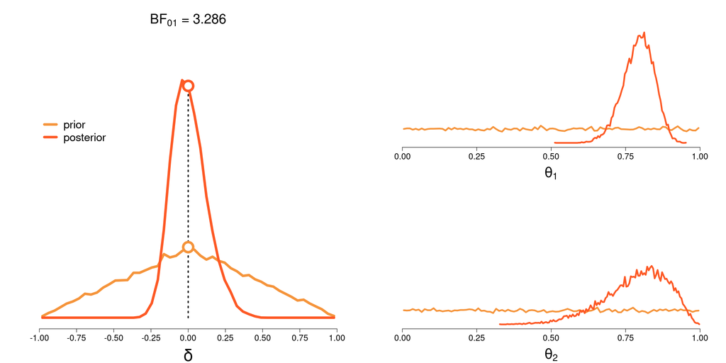

```r
brks <- seq(-1,1,length.out=50)
delta_prior <- hist(nds_delta$delta_prior,breaks=brks,plot=F)
delta_post <- hist(nds_delta$delta_post,breaks=brks,plot=F)
0%in%delta_prior$mids
0%in%delta_post$mids
prior_dens <- delta_prior$density[delta_prior$mids==0]
post_dens <- delta_post$density[delta_post$mids==0]

# Bayes Factor
BF_01 <- post_dens/prior_dens
print(paste('Factor de Bayes para delta=0:',BF_01))

col_prior <- '#f5943b'
col_post <- '#fd5925'

options(repr.plot.width = 18, repr.plot.height = 9)
layout(matrix(c(1,1,2,3),ncol=2,byrow=F))
# DELTA
plot(NULL,xlim=c(-1,1),ylim=c(0,4),axes=F,ann=F)
axis(1,at=seq(-1,1,0.25),cex.axis=1.5)
lines(delta_prior$mids,delta_prior$density,col=col_prior,lwd=6)
lines(delta_post$mids,delta_post$density,col=col_post,lwd=6)
lines(x=rep(0,2),y=c(0,max(prior_dens,post_dens)),lty='dotted',lwd=3)
points(x=rep(0,2),y=c(prior_dens,post_dens),pch=21,bg='#ffffff',cex=4,col=c(col_prior,col_post),lwd=6)
mtext('\u03b4',1,cex=2.5,line=4)
mtext(bquote(paste('BF'['01'],' = ',.(round(BF_01,3)))),3,cex=2)
legend(-1.2,3,legend=c('prior','posterior'),col=c(col_prior,col_post),
      lwd=6,seg.len=0.35,cex=2,x.intersp=0.2,y.intersp=0.65,
       bg='#ffffff00',text.width=.2,box.lty='blank')
# Theta
brks <- 100
theta1_prior <- hist(nds_delta$theta1_prior,breaks=brks,plot=F)
theta1_post <- hist(nds_delta$theta1_post,breaks=brks,plot=F)
theta2_prior <- hist(nds_delta$theta2_prior,breaks=brks,plot=F)
theta2_post <- hist(nds_delta$theta2_post,breaks=brks,plot=F)
# theta_1
plot(NULL,xlim=c(0,1),ylim=c(0,8),axes=F,ann=F)
axis(1,at=seq(0,1,0.25),cex.axis=1.5)
lines(theta1_prior$mids,theta1_prior$density,col=col_prior,lwd=4)
lines(theta1_post$mids,theta1_post$density,col=col_post,lwd=4)
mtext(expression(paste(theta[1])),1,cex=2,line=4)
# theta_2
plot(NULL,xlim=c(0,1),ylim=c(0,8),axes=F,ann=F)
axis(1,at=seq(0,1,0.25),cex.axis=1.5)
lines(theta2_prior$mids,theta2_prior$density,col=col_prior,lwd=4)
lines(theta2_post$mids,theta2_post$density,col=col_post,lwd=4)
mtext(expression(paste(theta[2])),1,cex=2,line=4)
```

### Diferencia entre Parámetros Normales

El método Savage-Dickey también sirve para evaluar posibles diferencias entre parámetros de distribuciones Normales. En el caso más sencillo, consideren dos grupos cuyas observaciones en cierta variable parecen normales, en el sentido de que al graficarlas en un histograma aparece la curva clásica:

```
   Min. 1st Qu.  Median    Mean 3rd Qu.    Max.
   3.60   37.10   51.90   51.85   66.58  115.00
```

```
   Min. 1st Qu.  Median    Mean 3rd Qu.    Max.
  35.70   44.20   46.65   46.84   50.12   59.90
```

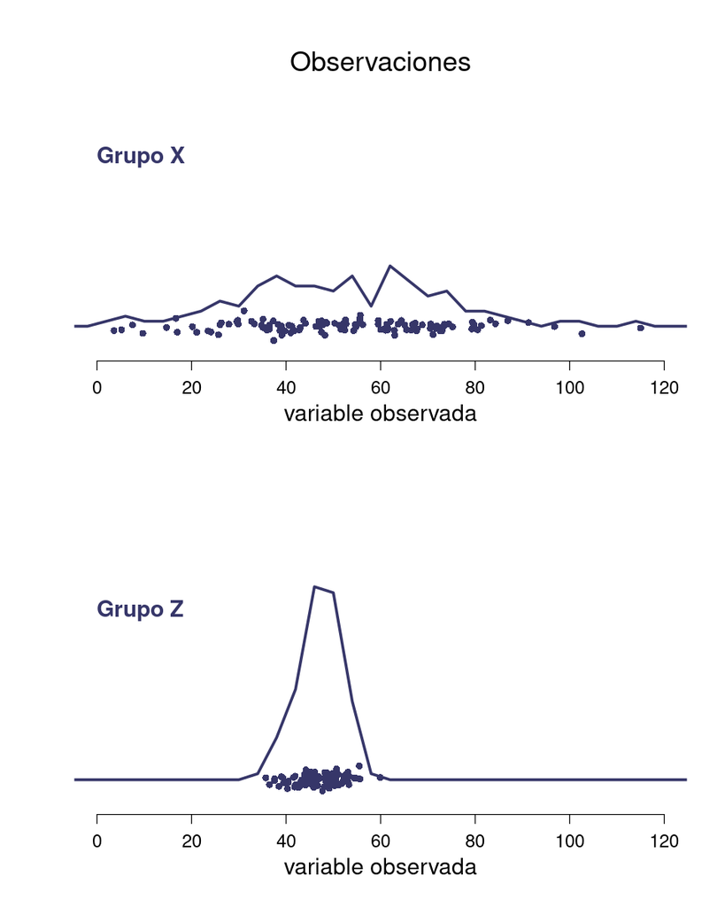

```r
rm(list=ls())
dset <- read.csv('~/Teaching/IAD-3/Notebooks/normal_groups.csv')

x <- dset$measure[dset$grupo=='grupo_X']
z <- dset$measure[dset$grupo=='grupo_Z']
summary(x)
summary(z)

hist_data <- function(obs,
                      ylimz=c(-0.01,.1),
                      xlimz=c(0,120),
                      postdiction=NULL,
                      label=NULL,
                      x_lab=NULL,
                     title=NULL){

  col_data <- '#363669'
    col_post <- '#208eb7'

  brks <- seq(-320,320,4)

  hist(obs,breaks=brks,plot=F)->hx

  plot(NULL,xlim=xlimz,ylim=ylimz,axes=F,ann=F)
  axis(1,cex.axis=1.2)
  lines(hx$mids,hx$density,lwd=3,col=col_data)
  points(obs,rnorm(n = length(obs),mean=0,sd=0.002),col=col_data,pch=16)
  if(!is.null(postdiction)){
    hist(postdiction,breaks=brks,plot=F)->hp
    lines(hp$mids,hp$density,col=col_post,lwd=6)
          legend(xlimz[2],ylimz[2]*.9,xjust=1,legend=c('datos','postdiccion'),
           lwd=5,col=c(col_data,col_post),box.lty='blank',
          seg.len=1,cex=1.4,y.intersp=.5,x.intersp=0.5,bg='#ffffff00')
  }
  text(xlimz[1],ylimz[2]*0.7,label,adj=0,cex=1.5,col=col_data,font=2)
    mtext(title,3,cex=1.8,line=0)
    mtext(x_lab,1,cex=1.5,line=2.5)
}

options(repr.plot.width = 8, repr.plot.height = 10)
layout(1:2)
hist_data(x,label='Grupo X',title='Observaciones',x_lab='variable observada')
hist_data(z,label='Grupo Z',x_lab='variable observada')
```

```r
head(dset)
```

A data.frame: 6 × 2

|  | grupo <chr> | measure <dbl> |
| --- | --- | --- |
| 1 | grupo_Z | 45.0 |
| 2 | grupo_X | 86.9 |
| 3 | grupo_Z | 39.5 |
| 4 | grupo_Z | 41.8 |
| 5 | grupo_Z | 48.5 |
| 6 | grupo_X | 46.3 |

A simple vista es evidente que las medidas de los grupos difieren en aspectos importantes: es claro que el grupo $X$ presenta una dispersión mayor que la del $Z$, y posiblemente las medias de ambos grupos también sean distintas. Además, es importante resaltar que *no* tenemos el mismo número de observaciones por grupo:

```r
n_x <- length(x)
n_z <- length(z)
n_x
n_z
```

120

100

En muchas aplicaciones la pregunta más importante (o al menos la más común) es si las *medias* de ambos grupos, $\mu_x$ y $\mu_z$, son iguales o diferentes. Para responderla podemos utilizar modelos similares al que empleamos en las diferencias entre tasas, pero ajustando para observaciones normales. En este primer modelo supondremos que la dispersión entre ambos grupos es la misma, aunque este supuesto ya se antoja ingenuo después de ver los histogramas de las observaciones.

$$\begin{align} \mu_x&\sim Gaussian(0,\tau=1/10^2)\\ \mu_z&\sim Gaussian(0,\tau=1/10^2)\\ \sigma&\sim Uniform(0,30)\\ \delta_\mu&\gets\mu_x-\mu_z\\ x_i&\sim Gaussian(\mu_x,1/\sigma^2)\\ z_j&\sim Gaussian(\mu_z,1/\sigma^2) \end{align}$$

[figure not shown]

```r
obs <- list('n_x','n_z','x','z')
unobs <- c('mean_x_prior','mean_x_post',
           'mean_z_prior','mean_z_post',
           'sd_prior','sd_post',
           'delta_mean_prior','delta_mean_post',
           'x_post',
           'z_post')

write('
model{

  mean_x_prior ~ dnorm(0,1/10^2)
  mean_x_post ~ dnorm(0,1/10^2)
  mean_z_prior ~ dnorm(0,1/10^2)
  mean_z_post ~ dnorm(0,1/10^2)
  sd_post ~ dunif(0,30)
  sd_prior ~ dunif(0,30)

  delta_mean_post <- mean_x_post-mean_z_post
  delta_mean_prior <- mean_x_prior-mean_z_prior

  for(i in 1:n_x){
    x[i] ~ dnorm(mean_x_post,1/sd_post^2) # Remember PRECISION!
  }
  x_post ~ dnorm(mean_x_post,1/sd_post^2)

  for(j in 1:n_z){
    z[j] ~ dnorm(mean_z_post,1/sd_post^2)
  }
  z_post ~ dnorm(mean_z_post,1/sd_post^2) # Remember PRECISION!

}
','delta_normal_equal_var.bug')
bys_equal_var <- jags(data = obs,
                      parameters.to.save = unobs,
                      model.file = 'delta_normal_equal_var.bug',
                      n.chains=4,
                      n.iter=2000,
                      n.burnin=1000,
                      n.thin=1)
summary(bys_equal_var$BUGSoutput$summary[,'Rhat'])
summary(bys_equal_var$BUGSoutput$summary[,'n.eff'])
nds_equal <- bys_equal_var$BUGSoutput$sims.list
```

```
   Min. 1st Qu.  Median    Mean 3rd Qu.    Max.
  1.001   1.001   1.001   1.001   1.001   1.004
```

```
   Min. 1st Qu.  Median    Mean 3rd Qu.    Max.
   1600    3200    4000    3518    4000    4000
```

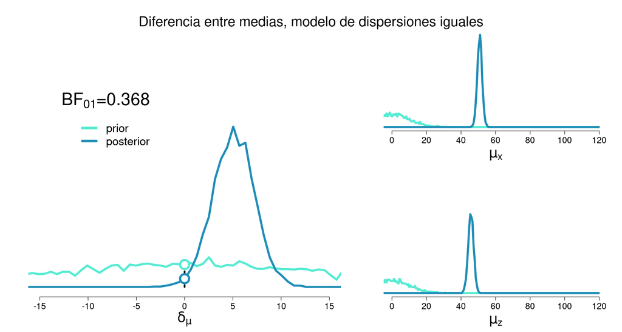

```r
hist_node <- function(node_prior,
                       node_post,
                      delta=F,
                      x_lab=NULL,
                       ylimz=c(0,0.3),
                       xlimz=c(-15,15),
                       brks=seq(-120,120,length.out=382)){

  col_prior <- '#56ebd3'
  col_post <- '#208eb7'

#  brks <- seq(-60,60,length.out=192)
  h_prior <- hist(node_prior,breaks=brks,plot=F)
  h_post <- hist(node_post,breaks=brks,plot=F)
  BF_01 <- h_post$density[h_post$mids==0]/h_prior$density[h_prior$mids==0]
  plot(NULL,xlim=xlimz,ylim=ylimz,axes=F,ann=F)
    axis(1,cex.axis=1.5)
    mtext(x_lab,1,line=3.5,cex=2)
  lines(h_prior$mids,h_prior$density,lwd=5,col=col_prior)
  lines(h_post$mids,h_post$density,lwd=5,col=col_post)
    if(delta){
  if(0%in%h_prior$mids&0%in%h_post$mids){
    lines(x=rep(0,2),
          y=c(0,max(h_prior$density[h_prior$mids==0],
                    h_post$density[h_post$mids==0])),
          lty='dotted',lwd=4)
    points(x=rep(0,2),
           y=c(h_prior$density[h_prior$mids==0],
                   h_post$density[h_post$mids==0]),
           pch=21,cex=3.5,lwd=5,bg='#ffffff',
           col=c(col_prior,col_post))

  }

  range_x <- xlimz[2]-xlimz[1]
  legend(xlimz[1]+range_x*.05,ylimz[2]*.7,
         xjust = 0,yjust = 1,
         legend=c('prior','posterior'),
         col=c(col_prior,col_post),
         y.intersp=0.75,x.intersp=.35,bg='#ffffff00',
         lwd=6,cex=2,seg.len=.5,box.lty='blank')
  text(xlimz[1]+range_x*0.075,ylimz[2]*.75,
       bquote(paste(BF['01'],'=',.(round(BF_01,3)))),
       cex=3,adj=0)
}
    }

options(repr.plot.width = 15, repr.plot.height = 8)
layout(matrix(c(1,1,2,3),ncol=2,byrow=F),widths=c(2,1.5))
hist_node(nds_equal$delta_mean_prior,
           nds_equal$delta_mean_post,
         delta=T,x_lab=expression(paste(delta[mu])))
hist_node(nds_equal$mean_x_prior,
           nds_equal$mean_x_post,xlimz=c(0,120),x_lab=expression(paste(mu[x])))
hist_node(nds_equal$mean_z_prior,
           nds_equal$mean_z_post,xlimz=c(0,120),x_lab=expression(paste(mu[z])))
mtext('Diferencia entre medias, modelo de dispersiones iguales',3,outer=T,line=-4,cex=2)
```

En otras palabras, el modelo de **dispersiones iguales** sugiere que la evidencia es ambigua, y que en todo caso **apunta a que las medias son diferentes**, $\delta_\mu\neq0$. Si bien esta conclusión podría parecer razonable, antes de tomarla por cierta es necesario decidir si el modelo es pertinente. Para ello debimos comenzar examinando la distribución postdictiva de este modelo:

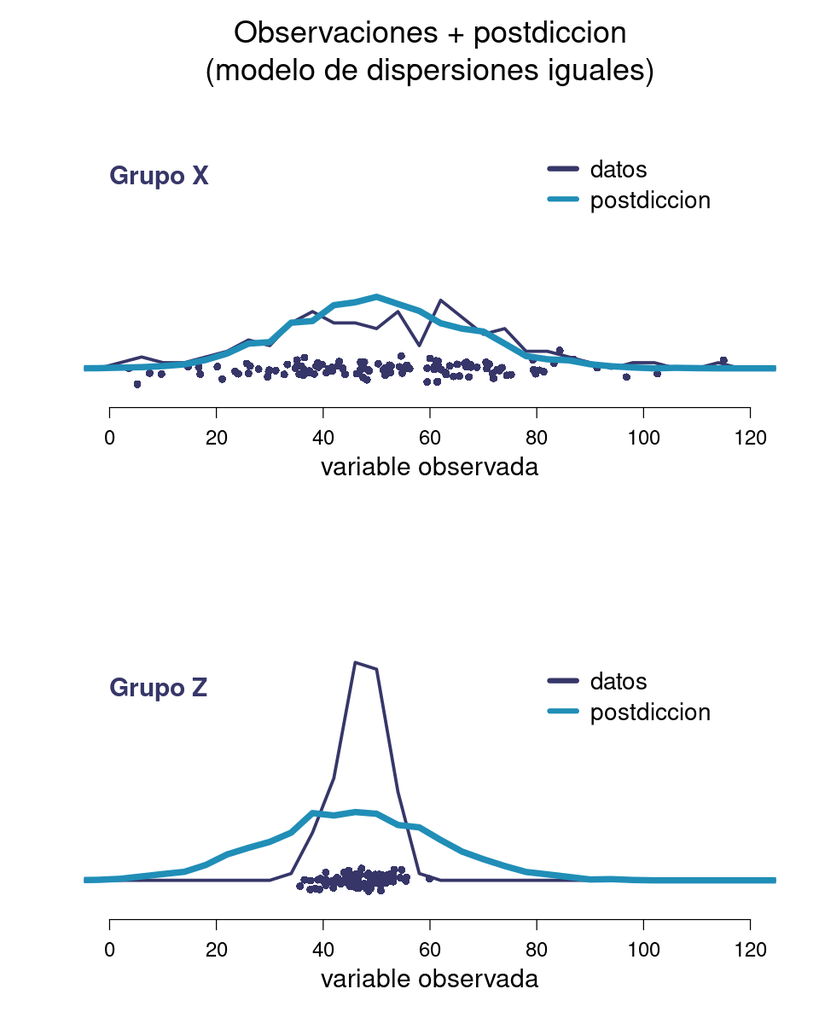

```r
options(repr.plot.width = 8, repr.plot.height = 10)
layout(1:2)
hist_data(x,label='Grupo X',postdiction = nds_equal$x_post,title='Observaciones + postdiccion\n(modelo de dispersiones iguales)',x_lab='variable observada')
hist_data(z,label='Grupo Z',postdiction = nds_equal$z_post,x_lab='variable observada')
```

Como consecuencia de suponer dispersiones iguales, este primer modelo tiene problemas para explicar las observaciones, en particular las del grupo $Z$: al aprender sobre una dispersión común a los dos grupos, espera que una nueva observación $z$ se comporte como la mayoría de las *todas* las observaciones, y como las observaciones en $x$, que son más numerosas, muestran una alta dispersión, el modelo concluye que la nueva observación $z$ debería de mostrar dispersión similar.

Con base en estos resultados podemos tratar de mejorar el desempeño del modelo suponiendo que cada grupo tiene una dispersión particular:

$$\begin{align} \mu_x&\sim Gaussian(0,\tau=1/10^2)\\ \mu_z&\sim Gaussian(0,\tau=1/10^2)\\ \sigma_x&\sim Uniform(0,30)\\ \sigma_z&\sim Uniform(0,30)\\ \delta_\mu&\gets\mu_x-\mu_z\\ \delta_\sigma&\gets\sigma_x-\sigma_z\\ x_i&\sim Gaussian(\mu_x,1/\sigma_x^2)\\ z_j&\sim Gaussian(\mu_z,1/\sigma_z^2) \end{align}$$

[figure not shown]

```r
unobs <- c('mean_x_prior','mean_x_post',
           'mean_z_prior','mean_z_post',
           'sd_x_prior','sd_x_post',
           'sd_z_prior','sd_z_post',
           'delta_mean_prior','delta_mean_post',
           'delta_sd_prior','delta_sd_post',
           'x_post',
           'z_post')

write('
model{

  mean_x_prior ~ dnorm(0,1/10^2)
  mean_x_post ~ dnorm(0,1/10^2)
  mean_z_prior ~ dnorm(0,1/10^2)
  mean_z_post ~ dnorm(0,1/10^2)
  sd_x_post ~ dunif(0,30)
  sd_z_post ~ dunif(0,30)
  sd_x_prior ~ dunif(0,30)
  sd_z_prior ~ dunif(0,30)

  delta_mean_post <- mean_x_post-mean_z_post
  delta_mean_prior <- mean_x_prior-mean_z_prior

  delta_sd_post <- sd_x_post-sd_z_post
  delta_sd_prior <- sd_x_prior-sd_z_prior

  for(i in 1:n_x){
    x[i] ~ dnorm(mean_x_post,1/sd_x_post^2) # Remember PRECISION!
  }
  x_post ~ dnorm(mean_x_post,1/sd_x_post^2)

  for(j in 1:n_z){
    z[j] ~ dnorm(mean_z_post,1/sd_z_post^2)
  }
  z_post ~ dnorm(mean_z_post,1/sd_z_post^2) # Remember PRECISION!

}
','delta_normal_diff_var.bug')

library('R2jags')
set.seed(123)
bys_diff_var <- jags(data = obs,
                     parameters.to.save = unobs,
                     model.file = 'delta_normal_diff_var.bug',
                     n.chains=4,
                     n.iter=2000,
                     n.burnin=1000,
                     n.thin=1)
summary(bys_diff_var$BUGSoutput$summary[,'Rhat'])
summary(bys_diff_var$BUGSoutput$summary[,'n.eff'])
nds_diff <- bys_diff_var$BUGSoutput$sims.list
```

```
   Min. 1st Qu.  Median    Mean 3rd Qu.    Max.
  1.001   1.001   1.001   1.001   1.001   1.002
```

```
   Min. 1st Qu.  Median    Mean 3rd Qu.    Max.
   1400    3250    4000    3467    4000    4000
```

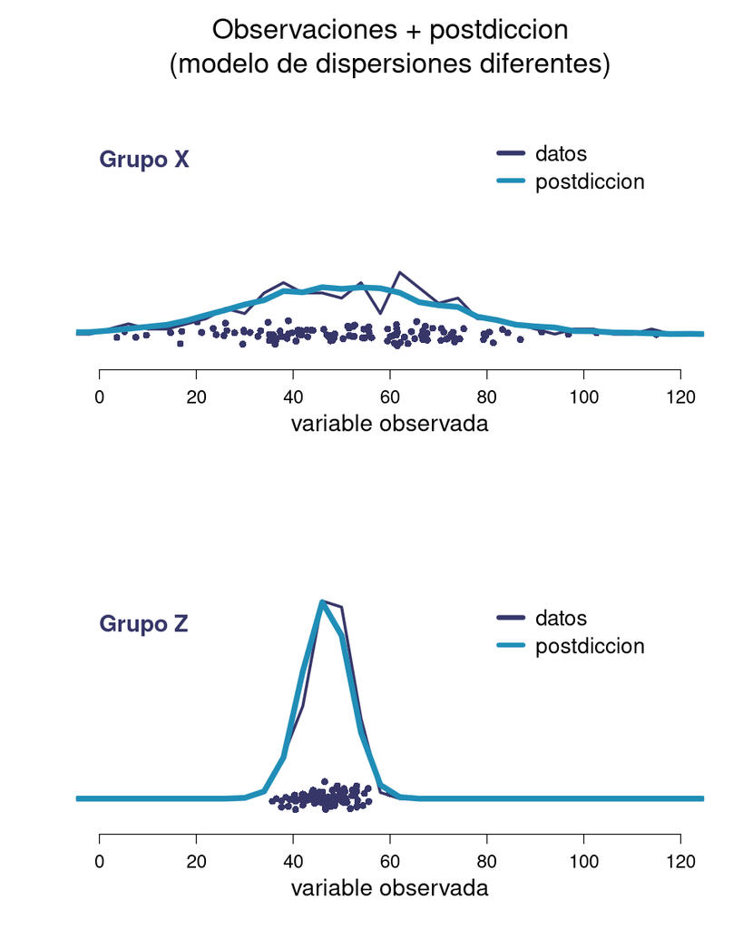

```r
options(repr.plot.width = 8, repr.plot.height = 10)
layout(1:2)
hist_data(x,label='Grupo X',postdiction = nds_diff$x_post,title='Observaciones + postdiccion\n(modelo de dispersiones diferentes)',x_lab='variable observada')
hist_data(z,label='Grupo Z',postdiction = nds_diff$z_post,x_lab='variable observada')
```

En contraste con el modelo anterior, el modelo de **dispersiones diferentes** muestra un mejor desempeño al explicar las observaciones de ambos grupos. Por lo tanto, deberíamos de confiar en las conclusiones de este modelo, o al menos preferirlas respecto del anterior. Examinando la diferencia entre medias:

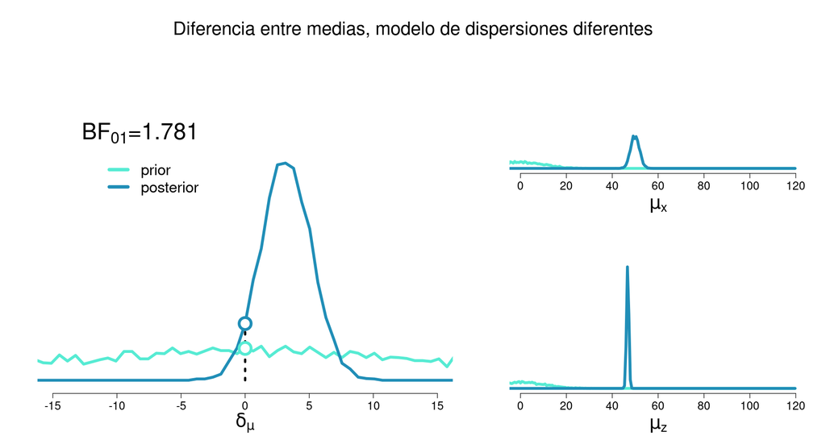

```r
options(repr.plot.width = 15, repr.plot.height = 8)
layout(matrix(c(1,1,2,3),ncol=2,byrow=F),widths=c(2,1.5))
hist_node(nds_diff$delta_mean_prior,
           nds_diff$delta_mean_post,
         delta=T,x_lab=expression(paste(delta[mu])))
hist_node(nds_diff$mean_x_prior,
           nds_diff$mean_x_post,xlimz=c(0,120),ylimz=c(0,0.8),x_lab=expression(paste(mu[x])))
hist_node(nds_diff$mean_z_prior,
           nds_diff$mean_z_post,
          xlimz=c(0,120),
         ylimz=c(0,0.8),x_lab=expression(paste(mu[z])))
mtext('Diferencia entre medias, modelo de dispersiones diferentes',3,outer=T,line=-4,cex=2)
```

Es decir, este modelo concluye *lo contrario* que el modelo anterior: el Factor de Bayes favorece al escenario $\delta_\mu=0$. Este resultado opuesto al del modelo precedente se debe a la precisión con la que este modelo puede inferir la media del grupo $z$, $\mu_z$; a su vez, dicha precisión se alcanza como consecuencia de suponer que ambos grupos tienen dispersiones diferentes: este modelo puede concluir que la dispersión de $z$ es menor que la de $x$, y por lo tanto tiene un rango más restringido de posibilidades para la *media* de $z$ respecto del que tenía el modelo anterior.

Una ventaja adicional de este modelo, y del método Savage-Dickey en general, es que también podemos proponer conclusiones sobre la diferencia entre *dispersiones* analizando el nodo correspondiente:

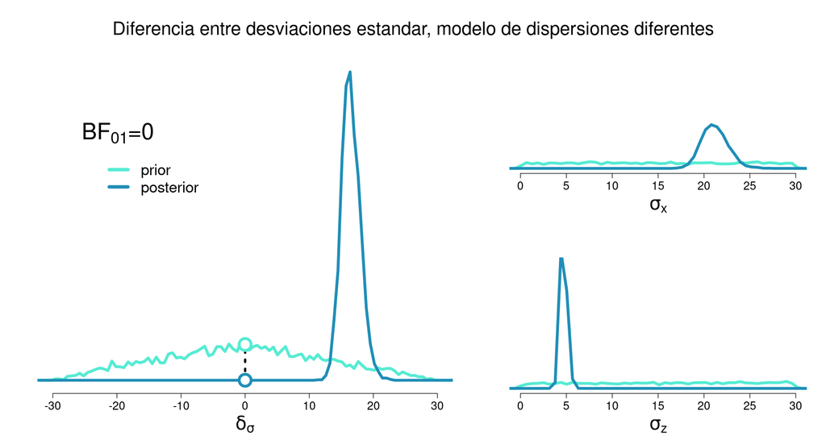

```r
options(repr.plot.width = 15, repr.plot.height = 8)
layout(matrix(c(1,1,2,3),ncol=2,byrow=F),widths=c(2,1.5))
hist_node(nds_diff$delta_sd_prior,
           nds_diff$delta_sd_post,
          xlimz=c(-30,30),
         delta=T,x_lab=expression(paste(delta[sigma])))
hist_node(nds_diff$sd_x_prior,
           nds_diff$sd_x_post,xlimz=c(0,30),ylimz=c(0,0.8),x_lab=expression(paste(sigma[x])))
hist_node(nds_diff$sd_z_prior,
           nds_diff$sd_z_post,
          xlimz=c(0,30),
         ylimz=c(0,0.8),x_lab=expression(paste(sigma[z])))
mtext('Diferencia entre desviaciones estandar, modelo de dispersiones diferentes',3,outer=T,line=-4,cex=2)
```

Es decir, el segundo modelo concluye que $\delta_\sigma\neq0$, o bien que las dispersiones de ambos grupos son distintas.

En general, las técnicas de inferencia Bayesiana permiten expresar modelos complejos de manera flexible e informar cada parámetro con toda la información disponible para ello (p.ej., con cantidades de información distintas por grupo, por persona, etcétera), mientras que el método Savage-Dickey permite cuantificar, en escala del Factor de Bayes, el soporte que ofrecen las observaciones para diferentes escenarios anidados dentro de dichos modelos.

Para profundizar, no dejen de consultar:

- Wagenmakers, E.-J., Lodewyckx, T., Kuriyal, H. & Grasman, R. (2010). Bayesian hypothesis testing for psychologists: A tutorial on the Savage-Dickey method. *Cognitive Psychology. 60*, 158-189.